# 03-ProbabilityDistributionsDiscrete

### Poisson Distribution

A Poisson distribution is a discrete probability distribution. It gives the probability of an event happening a certain number of times (k) within a given interval of time or space. The Poisson distribution has only one parameter, λ (lambda), which is the mean number of events

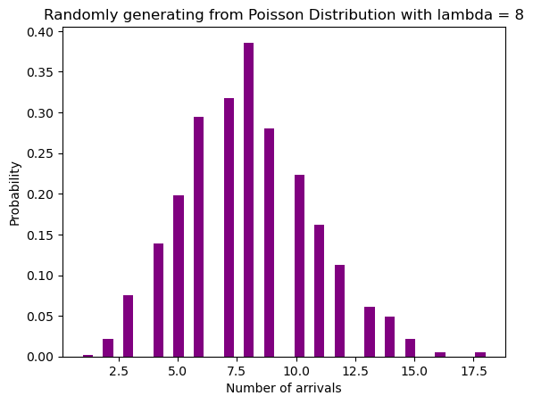

```python
import numpy as np
#arrival rate
lambda_ = 8
N = 1000
X = np.random.poisson(lambda_,N)


import matplotlib.pyplot as plt
counts, bins, ignored = plt.hist(X, 40, density = True, color = 'purple')
plt.title("Randomly generating from Poisson Distribution with lambda = 8")
plt.xlabel("Number of arrivals")
plt.ylabel("Probability")
plt.show()
```

### Uniform Distribution

- Uniform distribution refers to a type of probability distribution in which all outcomes are equally likely

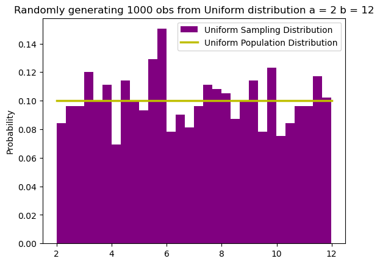

```python
import numpy as np
# parameters for the Uniform Distribution
a = 2
b = 12
N = 100

# Ranopmly generating 1000 observations from Uniform
X = np.random.uniform(a,b,1000)


# plotting the histogram of generated data from Uniform distribution
import matplotlib.pyplot as plt
count, bins, ignored = plt.hist(X, 30, density = True, color = 'purple', label = 'Uniform Sampling Distribution')

# ------ adding the population distribution with a and b ----------
# for x-axis the values need to go from a to b
x_values = np.linspace(a,b)
# for y-axis the values need to be all the same equal to 1/b-1
y_values = np.repeat(1/(b-a), len(x_values))

plt.plot(x_values, y_values, linewidth = 2.5, color = 'y', label = 'Uniform Population Distribution')
plt.title("Randomly generating 1000 obs from Uniform distribution a = 2 b = 12")
plt.ylabel("Probability")
plt.legend()
plt.show()
```

### Normal Distribution

Normal distribution, also known as the Gaussian distribution, is a probability distribution that is symmetric about the mean, showing that data near the mean are more frequent in occurrence than data far from the mean.

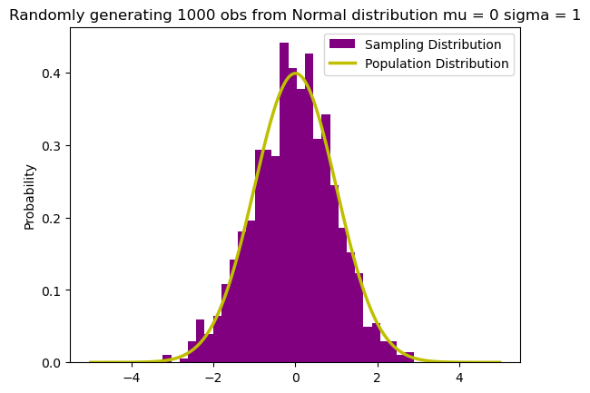

```python
import numpy as np
mu = 0
sigma = 1
N = 1000
X = np.random.normal(mu,sigma,N)

# Population distribution
from scipy.stats import norm
x_values = np.arange(-5,5,0.01)
y_values = norm.pdf(x_values)

import matplotlib.pyplot as plt
counts, bins, ignored = plt.hist(X, 30, density = True,color = 'purple',label = 'Sampling Distribution')
plt.plot(x_values,y_values, color = 'y',linewidth = 2.5,label = 'Population Distribution')
plt.title("Randomly generating 1000 obs from Normal distribution mu = 0 sigma = 1")
plt.ylabel("Probability")
plt.legend()
plt.show()
```

### Binomial Distribution

The binomial distribution is the discrete probability distribution that gives only two possible results in an experiment, either Success or Failure

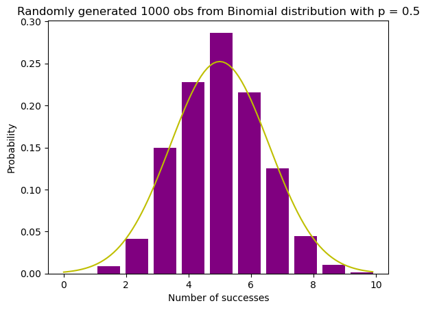

```python
import numpy as np
#Random Generations of 1000 independent Binomial samples
# (fair coin tosses 10 times in each experiment) 1000 times
n = 10
p = 0.5
N = 1000
X = np.random.binomial(n,p,N)

#Plotting Binomial distribution and adding Normal distribution line
import matplotlib.pyplot as plt
from scipy.stats import norm

# population mean and sigma
mu = n*p
sigma = np.sqrt(n*p*(1-p))
x_values = np.arange(0,10,0.1)


# histogram of Binomial distribution
counts, bins, ignored = plt.hist(X, 10, density = True, rwidth = 0.8, color = 'purple')

# Plot of Normal distribution
plt.plot(x_values, norm.pdf(x_values, mu,sigma), color = 'y', linewidth = 1.5)
plt.title("Randomly generated 1000 obs from Binomial distribution with p = 0.5")
plt.xlabel("Number of successes")
plt.ylabel("Probability")
plt.show()
```

```python
import numpy as np
two_rej = np.random.binomial(20, 0.12, 10)
```

```python
two_rej
```

```
array([1, 3, 1, 1, 2, 1, 3, 4, 2, 1])
```

```python
import matplotlib.pyplot as plt
import seaborn as sns
sns.set_theme(style="whitegrid")
```

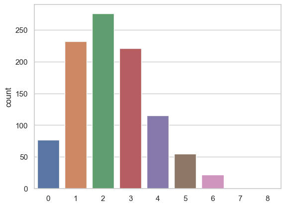

```python
two_rej = np.random.binomial(20, 0.12, 1000)
# import matplotlib.pyplot as plt
# import seaborn as sns
# np.random.seed(555)       # By using seed you can make sure that each time you get the same numbers
sns.set_theme(style="whitegrid")
sns.countplot(x=two_rej)
plt.show()
```

### **Bernoulli distribution**

Bernoulli distribution is a discrete probability distribution. It describes the probability of achieving a “success” or “failure” from a Bernoulli trial. A Bernoulli trial is an event that has only two possible outcomes (success or failure).

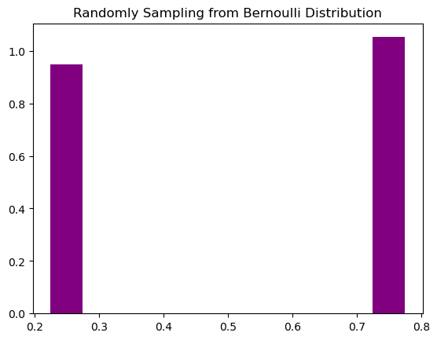

```python
import numpy as np
# (coin tosses 10 times in each experiment)
n = 1
p = 0.5
N = 1000
# Bernoulli distribution  = binomial with n = 1
X = np.random.binomial(n,p,N)


import matplotlib.pyplot as plt
counts, bins, ignored = plt.hist(X, 2, density = True, rwidth = 0.1, color = 'purple')
plt.title("Randomly Sampling from Bernoulli Distribution")
plt.show()
```

### Geometric Distribution

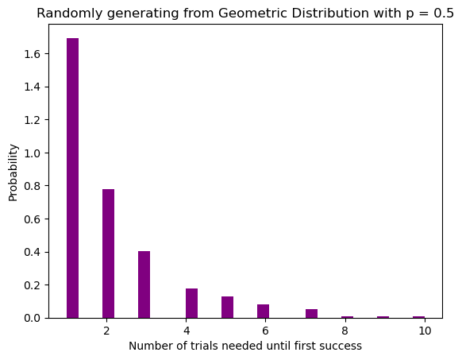

```python
import numpy as np
p = 0.5
N = 1000
X = np.random.geometric(p,N)


import matplotlib.pyplot as plt
count, bins,ignored = plt.hist(X, 30, density = True, color = 'purple', rwidth = 1)
plt.title("Randomly generating from Geometric Distribution with p = 0.5")
plt.xlabel("Number of trials needed until first success")
plt.ylabel("Probability")
plt.show()
```

### Poisson Distribution

A Poisson distribution is a discrete probability distribution. It gives the probability of an event happening a certain number of times (x) within a given interval of time or space. The Poisson distribution has only one parameter, λ (lambda), which is the mean number of events

The Poisson distribution describes the probability of obtaining x successes during a given time interval.

Poisson distribution is the discrete probability distribution which represents the probability of occurrence of an event x number of times in a given interval of time or space if these events occur with a known constant mean rate and are independent of each other. This type of probability is used in many cases where events occur randomly, but with a known average rate. The number of events that happen during an interval is dependent on the time elapsed rather than the total time available. The Poisson distribution can be applied to time-sensitive processes such as text messages sent per minute and phone calls received per second. Poisson distribution can help us determine how often we may expect an “event” such as finding customers in line or the number of accidents that occur per hour.

**The number of customers visiting the supermarket:** In a supermarket, how many customers visit the store per day is an example of Poisson distribution. If the average number of customers visiting a supermarket on weekdays is 50, then knowing this information can help the store managers decide how many staff members are needed for serving the customers. The number of phone calls in the call center: The number of phone calls received by a call center in one day can be considered as an example of a Poisson distributed random variable. In this case, it will help to determine whether or not there are any irregularities that need immediate attention from managers.

**The number of defective items produced by a factory:** The number of defective goods that are made in one production run can be considered as an example of Poisson distribution. This is important for quality control purposes to ensure that customers are getting the right kind and quantity of products they pay for. If the average number of defective items produced by the factory per day is ten, then this information can be used to determine how many inspectors are needed for checking these goods or if there needs to be an increase in production capacity.

[figure not shown]

```python
from scipy.stats import poisson

# random values from Poisson distribution with mean=4 and sample size=12
poisson.rvs(mu=4, size=12)
```

```
array([5, 5, 5, 3, 8, 4, 4, 5, 3, 3, 4, 4], dtype=int64)
```

- Calculate Probabilities Using a Poisson Distribution
  - poisson.pmf(k, mu) and poisson.cdf(k, mu) functions to calculate probabilities related to the Poisson distribution

**Question** A seller sells 3 Television per day on average. What is the probability that the seller will sell 5 Televisions on a given day?

```python
from scipy.stats import poisson

#calculate probability
poisson.pmf(k=5, mu=3)
```

```
0.10081881344492458
```

**Question** - A certain store sells nine doormats per day on average. What is the probability that this store sells five or less doormats in a given day?

```python
from scipy.stats import poisson

#calculate probability
poisson.cdf(k=5, mu=9)
```

```
0.1156905208410578
```

**Question** - Let’s say that the number of trains that come on a bus stop in span of 30 minutes is 1. Poisson distribution can be used to model the probability of different number of trains, X, coming to the train station within the next 30 minutes where X can take value of 0, 1, 2, 3, 4.

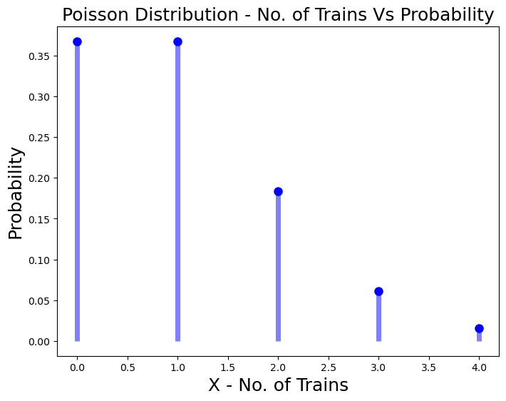

```python
from scipy.stats import poisson
import matplotlib.pyplot as plt
#
# Random variable representing number of trains
# Mean number of trains coming to train station in 30 minutes is 1
#
X = [0, 1, 2, 3, 4]
lmbda = 1
#
# Probability values
#
poisson_pd = poisson.pmf(X, lmbda)
#
# Plot the probability distribution
#
fig, ax = plt.subplots(1, 1, figsize=(8, 6))
ax.plot(X, poisson_pd, 'bo', ms=8, label='poisson pmf')
plt.ylabel("Probability", fontsize="18")
plt.xlabel("X - No. of Trains", fontsize="18")
plt.title("Poisson Distribution - No. of Trains Vs Probability", fontsize="18")
ax.vlines(X, 0, poisson_pd, colors='b', lw=5, alpha=0.5)
```

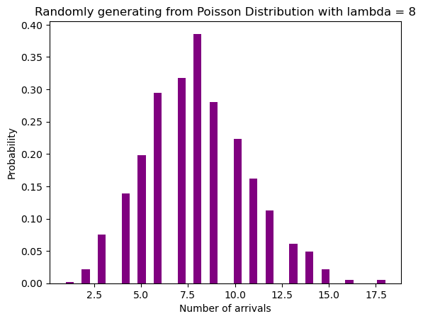

```python
import numpy as np
#arrival rate
lambda_ = 8
N = 1000
X = np.random.poisson(lambda_,N)


import matplotlib.pyplot as plt
counts, bins, ignored = plt.hist(X, 40, density = True, color = 'purple')
plt.title("Randomly generating from Poisson Distribution with lambda = 8")
plt.xlabel("Number of arrivals")
plt.ylabel("Probability")
plt.show()
```

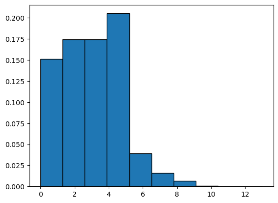

```python
from scipy.stats import poisson
import matplotlib.pyplot as plt

#generate Poisson distribution with sample size 10000
x = poisson.rvs(mu=3, size=10000)

#create plot of Poisson distribution
plt.hist(x, density=True, edgecolor='black')
```

### Student t Distribution

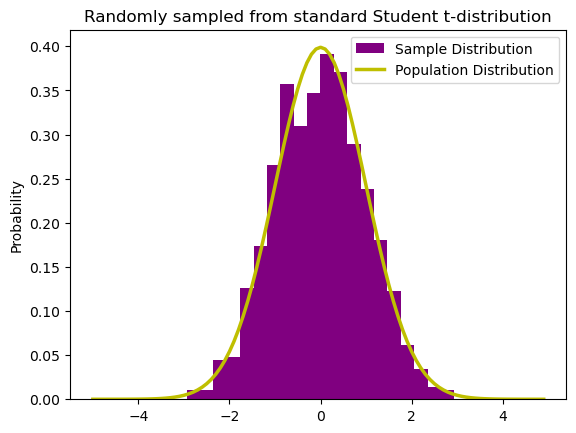

```python
import numpy as np

# randomly sampling 100 obsev from t-distribution
N = 1000
df = N-1
X = np.random.standard_t(df, size = N)


import matplotlib.pyplot as plt
from scipy.stats import t

x_values = np.arange(-5,5,0.1)
y_values = t.pdf(x_values,df)
# Sample Distribution
count, bins, ignored = plt.hist(X, 20, density = True,color = 'purple',label = 'Sample Distribution')
# Population Distribution
plt.plot(x_values,y_values, color = 'y', linewidth = 2.5,label = 'Population Distribution')
#adding title and y-label
plt.title("Randomly sampled from standard Student t-distribution")
plt.ylabel("Probability")
plt.legend()
plt.show()
```